# Знакомимся со сложностью алгоритмов

## Зачем мы учим сортировки?

В 1 семестре вас заставляют писать несколько кодов, каждый из которых решает одну и ту же задачку (сортировка массива). Собственно, назревает вопрос: **а зачем нам учиться писать какие-то странные функции, которые мы никогда не будем использовать в жизни, более того, они ведь еще и задачку одну решают!?** Причины, на самом деле, 2! Рассмотрим каждую из них:

### Причина №1: алгоритмы сортировок как наука о решении любой задачи

Так получилось, что алгоритмы сортировок уж очень отличаются друг от друга; в каждом из этих алгоритмов используются разные способы решения задач, например, это конструкция `for внутри for`, `рекурсия`, `цикл while`, `вызов одной функции внутри другой`. Таким образом, изучив разные алгоритмы сортировок, вы научитесь использовать разные конструкции языков программирования, каждая из которых поможет вам в дальнейшем решить другие задачи, более направленные на вашу деятельность.

### Причина №2: алгоритмы сортировок как изучение сложности

Изучая разные алгоритмы, решающую одну задачу, вы также можете научиться определять, какой алгоритм лучше! Понятие “лучше” уж очень гуманитарно абстрактно , поэтому информатики решили его формализировать. Вылилось это в что-то более конкретное, а именно в **сложности**. Сложность алгоритма позволяет определять, какой из алгоритмов более “хорошо” написан.

Итак, изучая разные алгоритмы сортировок, вы также на конкретных примерах учитесь понимать, как писать код *проще* (то есть с меньшей сложностью).

## Разнообразие сложностей и сложность по скорости

Сложность можно вычислять по-разному. Один из вариантом - это оценивать память, которую ваш алгоритм занимает на вашем устройстве, другой способ - определять *скорость* работы алгоритма, то есть количество операций, которые ваш компьютер должен выполнить для решения задачи.

Почему это важно? Важно это по одной простой причине: кол-во итераций, которое выполняет ваш компьютер, напрямую связано со временем выполнения вашего алгоритма. В программах, которые вы пишете на первом курсе, скорость выполнения вашим компьютером составляет менее секунды, вы ее даже не ощущаете, но такое, к сожалению, может быть не всегда. Бывают коды, которые перед тем как дать ответ, могут выполняться неделями! Возможно, некоторые из вас познакомятся с такими программами на 4-ом курсе.

Если до сих пор думаете, что компьютер не может выполнять программу слишком долго, то вот наглядный пример того, как размер данных влияет на скорость работы.

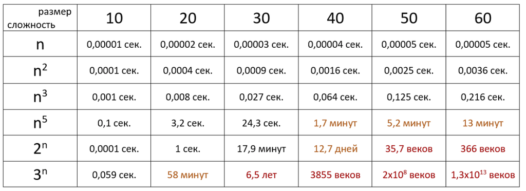

А сейчас пока можете подумать еще над способами вычисления *сложности* алгоритма. Может в будущем ваш способ будет изучаться в университетах :)

**Замечание:** На данном курсе мы с вами остановимся только на сложности по скорости, которая тоже может быть разной.

### Наглядный пример:

Предположим у нас есть массив $(1, 0, 2, 3, 4, 5)$. Мы хотим отсортировать данный массив методом “пузырька”, то есть сравнивая попарно каждые элементы в данном массиве, и если элемент справа меньше элемента слева, то мы их меняем местами. Вы уже писали данную программу, поэтому знаете, как такая функция устроена.

Итак, начнем менять элементы:

*На шаге №1* мы берем 1 и 2 элементы (то есть 1 и 0). Мы видим, что 0 < 1, поэтому мы меняем их местами, после чего получаем массив $(0, 1, 2, 3, 4, 5)$, который уже является **отсортированным**!

Итак, нам с вами понадобилась всего 1! раз пробежаться по массиву, чтобы его отсортировать, и это вроде звучит неплохо.

Теперь представим, что элементы в массиве расположены так: $(5, 4, 3, 2, 1, 0)$, и нам опять нужно отсортировать такой массив в порядке *возрастания*. Сколько в таком случае нам понадобится итераций? Подумайте над этим :)

### Сложности в хорошем и плохом случае:

На рассмотренном примере мы с вами выяснили, что *в зависимости от исходных данных один и тот же алгоритм может справляться с задачей с разной скоростью*. Умные информатики заметили это намного раньше нас и решили разделять сложность по скорости на разные категории, а именно:

1. Сложность в худшем случае (для “пузырька” в рассмотренном нами примере это массив$(5, 4, 3, 2, 1, 0)$)
2. Сложность в лучшем случае (для “пузырька” в рассмотренном нами примере это массив $(1, 0, 2, 3, 4, 5)$)
3. Сложность в среднем

**Замечание:** В данном курсе мы будем рассматривать только сложность *в худшем случае*, поэтому если вас просят в домашке посчитать сложность, подразумевается худший случай.

### Какие значения может принимать сложность?

Из курса математического анализ известен ряд, который отражает скорость роста различных видов зависимостей. Вот он в отсортированном порядке (от медленной функции к быстрой):

$$log_2n << n << n \cdot log_2n << n^a, a>1 << \alpha^n (пример: e^n) << n! << n^n$$

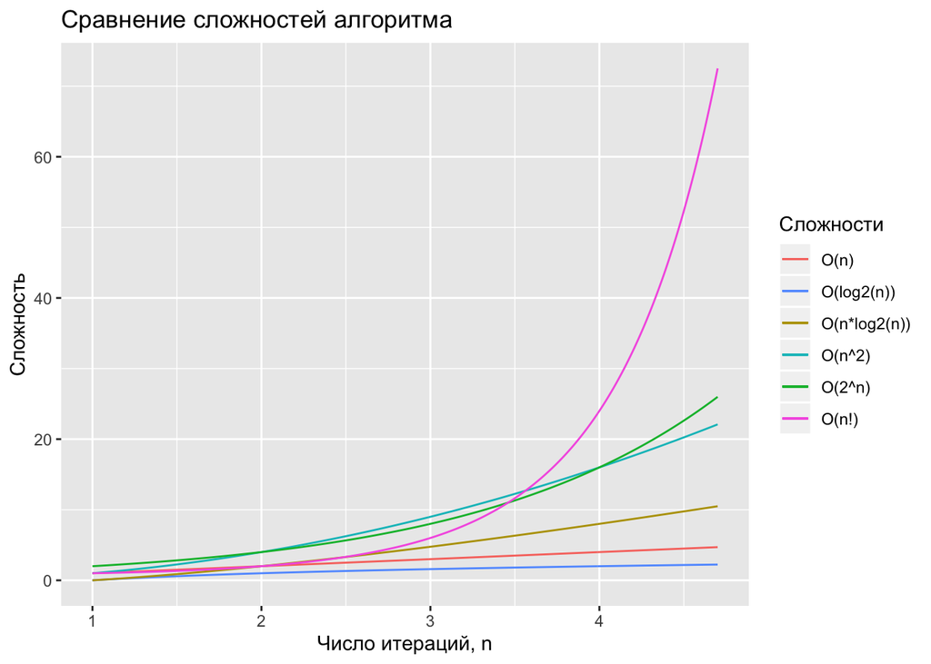

### Принятые свойства

Обычно, при вычислении сложности принято округлять значение до наиболее значимого веса (наибольшего порядка) и игнорировать константы, то есть, например, считается, что:

1. $O(\frac{1}{2}n + 1) = O(n)$ - константы не учитываются
2. $O(n^2 + n) = O(n^2)$ - берем только наибольший порядок ($n^2$)
3. $O(\frac{1}{2}n^2 + n + 1) = O(n^2)$ - все вместе

**Важное замечание:** сложность алгоритма записывается в общем случае! То есть как функция от $n$.  
**Важное замечание:** если в домашке вы округляете сложность алгоритма, пишите полностью вывод!

## Переходим к практике

Давайте теперь на примере разных кодов научимся считать сложности сами!

Перед этим стоит отметить, что мы будем обозначать нашу сложность через символ $O$, который называется О-большое.

### Пример №1

Есть код:

```r
m <- matrix(1:9, nrow = 3, byrow = TRUE)
print(m)
```

```
##      [,1] [,2] [,3]
## [1,]    1    2    3
## [2,]    4    5    6
## [3,]    7    8    9
```

```r
for (i in 1:nrow(m)){
  for (j in 1:ncol(m)){
    print(m[i,j])
  }
}
```

```
## [1] 1
## [1] 2
## [1] 3
## [1] 4
## [1] 5
## [1] 6
## [1] 7
## [1] 8
## [1] 9
```

Задача: посчитать сложность алгоритма

Решение:

Итак, мы с вами знаем, что `for внутри for` означает, что для каждой переменной из первого `for` берется заданное кол-во переменных из второго `for`. В данном примере, для каждой переменной $i$ от 1 до `nrow(m)` будет браться переменная $j$ $ncol(m)$ раз. $nrow(m)$ -это число строк в матрице $m$ (в данном случае 3), а $ncol(m)$ - это число столбцов в матрице $m$ (в данном случае тоже 3, матрица квадратная).

Если чуть-чуть подумать, можно определить, что совокупное число итераций в данной задаче равно $nrow(m) \cdot ncol(m)$ раз (или $3 \cdot 3 = 9$, или $n * n = n^2$). Соответственно, сложность нашей задачи $O(n^2)$.

### Пример №2

Есть код:

```r
n <- 4
for (i in 1:n){
  for (j in 1:(n-1)){
  }
}
```

Задача: вычислить сложность

Решение:

В первом цикле $n$ итераций, во вложенном втором цикле - $(n-1)$. Следовательно наша сложность: $O(n \cdot (n-1)) = O(n^2 - n) = O(n^2)$.

### Пример №3. Откуда в сложности берется логарифм?

Есть код:

```r
x <- 10
for (i in 1:4){
   x <- x / 2
   print(x)
}
```

```
## [1] 5
## [1] 2.5
## [1] 1.25
## [1] 0.625
```

Код очень простой, он делит $x$ на 2 четыре раза. Функция `print(x)` позволяет нам это явно увидеть.

Итак, мы делим $x$ на 2 четыре раза, следовательно число наших операций = 4. Если мы посмотрим на эту задачку с конца, то можем заметить, что $x$ = $2^4$ что довольно логично.

Код №2:

```r
x <- 10
while (x > 0) {
   x <- x / 2
}
```

Этот код тоже очень простой. Цикл `while` говорит нам делить $x$ на 2, *пока* выполняется условие $x > 0$.

Однако здесь уже число итераций посчитать довольно сложно, ведь мы не знаем сколько раз надо разделить число 10 на 2, чтобы получить 0. Да и разве получим мы его вообще? Скорее только очень-очень близкое к нулю число.

Итак, для того чтобы вычислить число операций алгоритма, а следовательно и сложность, нужно вспомнить определение *логарифма по степени 2*. Здесь вы должны помнить, что $log_216 = 4$, так как $2^4 = 16$.

Ранее, мы определили, что $2^k = x$, где $k -$ число итераций. Ну тогда, используя определение логарифма: $k = log_2(x)$. Следовательно, наша сложность $O(log_2x)$.

Если кто-то хочет побольше почитать про сложность $O(log_2n)$, то бегом [читать сюда про задачу бинарного поиска](https://ru.wikipedia.org/wiki/Двоичный_поиск).

## Краткий гайд по сложностям сортировок

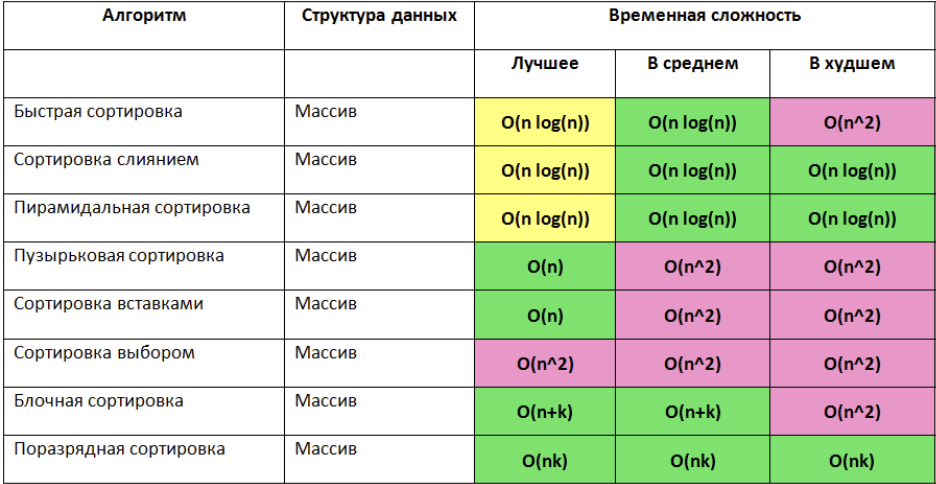

## Что еще почитать?

[Статья на хабре про сложности разных алгоритмов](https://habr.com/ru/post/188010/)

[Очень крутая книга по алгоритмам](https://www.ozon.ru/context/detail/id/139296295/)